# Baseline and Sensitivities

```r
library(plyr)
library(tidyverse)
resultsfolder = "/Applications/storagevet2v101/StorageVET-master-git/Results/"
# output = read_csv(file = paste0(resultsfolder,"npv_runs51-76.csv"))
# runslog = read_csv(file = paste0(resultsfolder,"runsLog.csv"))
# output = merge(output, runslog[,c("runID","shortname", "description")], by = "runID")
source("/Applications/storagevet2v101/StorageVET-master-git/combine_results.R")
output = combine_results(runIDs = c(134,145), savecsv=F, plotTF=F) #41:48, 78:85, or 86:93, #51:76,94
dark2scale =c('#1b9e77','#d95f02','#7570b3','#e7298a','#66a61e','#e6ab02','#a6761d','#666666')
scale = (c("#2f4f4f","#8b4513","#228b22","#000080","#ff0000","#ffff00","#00ff00","#00ffff","#ff00ff","#eee8aa","#6495ed","#ff69b4"))
darkscale = c(dark2scale,scale)
output$ITC = 0#output$`2MW-5hr Capital Cost` * 0.26
fivehbatt = output$shortname != "baseline1_4hbatt"
output$SGIP[fivehbatt] = 10000 * 350 * -1
output$SGIP[!fivehbatt] = 8000 * 350 * -1
output$unsub_total = output$total
output$total = output$unsub_total - output$ITC - output$SGIP #subsidies are negative so that they show up against capital cost
output$`2MW-5hr Capital Cost` = output$`2MW-5hr Capital Cost` - output$ITC - output$SGIP
outputbl1 = filter(output, str_detect(shortname,"baseline1"))
outputbl2 = filter(output, str_detect(shortname,"baseline2"))
baselines = filter(output, shortname == "baseline1" | shortname =="baseline2" | shortname == "baseline1_4hbatt")
```

Sensitivities were performed on an optimistic and pessimistic baseline. These are the sensitivities applied to the optimistic baseline, which assumes a 15 yr lifetime,

```r
sensitivities1 = read_csv("/Applications/storagevet2v101/StorageVET-master-git/Data/baseline1_sensitivities.csv")
print(sensitivities1)
```

| var | new_value |
| --- | --- |
| Finance_npv_discount_rate | 5 |
| Finance_npv_discount_rate | 10 |
| Battery_ccost_kwh | 500 |
| Scenario_end_year | 2029 |
| Scenario_end_year | 2039 |
| Scenario_n | 120 |
| Battery_daily_cycle_limit | 1 |
| Battery_daily_cycle_limit | 2 |
| Battery_hp | 100 |
| Scenario_monthly_data_filename | /Applications/storagevet2v101/StorageVET-master-git/Data/Monthly_Data_6-kW_RA.csv |

[output cut: 2 more lines]

# Optimistic v Pessimistic Baseline

The two baselines differ in their capital costs and resulting ITC benefits. As well, the longer lifetime of the optimistic scenario likely drives higher overall revenues. As well, the optimistic baseline (baseline 1) participates more in energy arbitrage (DA ETS) than the pessimistic version; this is likely driven by the cap in daily cycles at 1 per day (as informed by sensitivity analysis below). Without the daily cycle limit, the optimistic scenario also provides more spinning reserves.

[figure not shown]

```r
tallbaseline = pivot_longer(baselines, cols = c(-runID,-total,-unsub_total,-outputfol,-shortname,-description),names_to = "value_type", values_to = "value")  #removed -keyFn
# tallbaseline$name = substr(talloutput$outputfol,10,100)
tallbaseline$value_type = ordered(tallbaseline$value_type, levels = rev(c("DA ETS","FR Energy Throughput","Regulation Up","Regulation Down","Spinning Reserves","Non-Spinning Reserves",
                                                                        "Resource AdequacyCapacity Payment", "2MW-5hr Capital Cost","2MW-5hr Fixed O&M Cost","2MW-5hr Variable O&M Costs",
                                                                        "Site Load Capital Cost","Site Load Fixed O&M Cost",
                                                                        "Aux Load Cost","ITC","SGIP")))
# tallbaseline = tallbaseline %>%
#   arrange(value_type)
# ggplot(tallbaseline ,aes(fill = value_type, x = reorder(shortname,-total), y = value)) +
#     geom_bar(position="stack", stat = "identity") +
valuescale =c("light grey",'#1b9e77','#666666',"#2f4f4f","#8b4513",'#e7298a','#d95f02','#7570b3','#66a61e',#"#228b22",
              '#e6ab02',
'#a6761d',"#6495ed","#000080")
ggplot(filter(tallbaseline,value!=0) ,aes(x = reorder(shortname,-total), y = value, fill = value_type)) +
    geom_bar(stat = "identity") +
    geom_hline(yintercept = 0, color = "black") +
    theme_minimal() +
    theme(axis.text.x = element_text(angle = 50, vjust = 1, hjust=1)) +
    scale_y_continuous(labels = scales::dollar_format()) +
    scale_fill_manual(values=valuescale)
```

## Total NPV

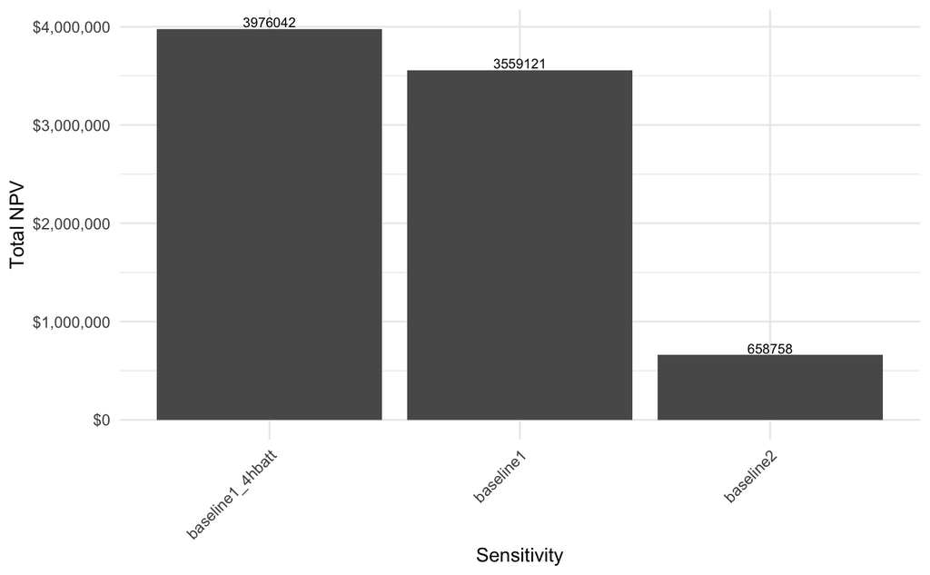

```r
ggplot(baselines,aes(x = reorder(shortname,-total), y = total)) + geom_col() +
  theme_minimal() +
  scale_y_continuous(labels = scales::dollar_format()) +
  theme(axis.text.x = element_text(angle = 45, vjust = 1, hjust=1)) +
  labs(y = "Total NPV", x="Sensitivity")+
  geom_text(aes(label=round(total)), vjust=-0.2, size = 2.7)
```

# Revenue Sources in Baseline Runs

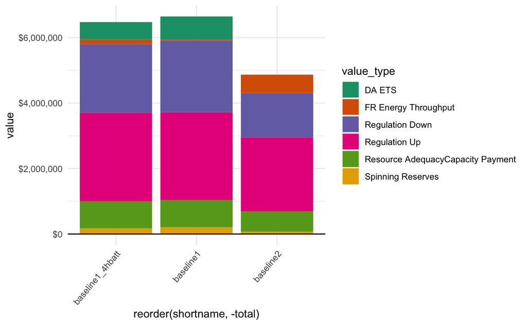

```r
tallbaseline = pivot_longer(baselines, cols = c(-runID,-total,-unsub_total,-outputfol,-shortname,-description),names_to = "value_type", values_to = "value")  #removed -keyFn
# tallbaseline$name = substr(talloutput$outputfol,10,100)
tallbaselinerevenue = filter(tallbaseline, value>0)
ggplot(tallbaselinerevenue ,aes(fill = value_type, x = reorder(shortname,-total), y = value)) +
    geom_bar(position="stack", stat = "identity") +
    geom_hline(yintercept = 0, color = "black") +
    theme_minimal() +
    theme(axis.text.x = element_text(angle = 50, vjust = 1, hjust=1)) +
    scale_y_continuous(labels = scales::dollar_format()) +
    scale_fill_manual(values=dark2scale)
```

# Sensitivity results on NPV - optimistic baseline

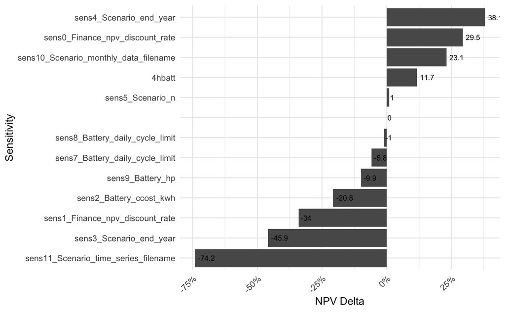

# Sensitivity results on NPV - pessimistic baseline

Most to least important effects examined: 1. Length of project (double), 2. FR prices, 3. length of project (10 -> 15 yrs), 4. capital cost (decrease 500 > 400/kWh, or by 20%), 5. Increase RA prices (double), 6. Discount rate (increasing to 10% or decreasing to 5% from 7%), 7. Removing housekeeping power 8. Remove daily cycle limit 9. Increase length of simulation

The results are qualitatively similar to the sensitivities done on the optimistic baseline. Project lifetime and FR prices are very important to both; cycle limit and simulation length are relatively unimportant for each. The two show differet results in the importance of capital cost, which is more important in the pessimistic case than RA prices or discount rate. In the optimistic case, capital cost is less important than these other two factors. This difference can be likely attributed to the difference in project lifetime, since a larger lifetime effectively deweights the upfront cost.

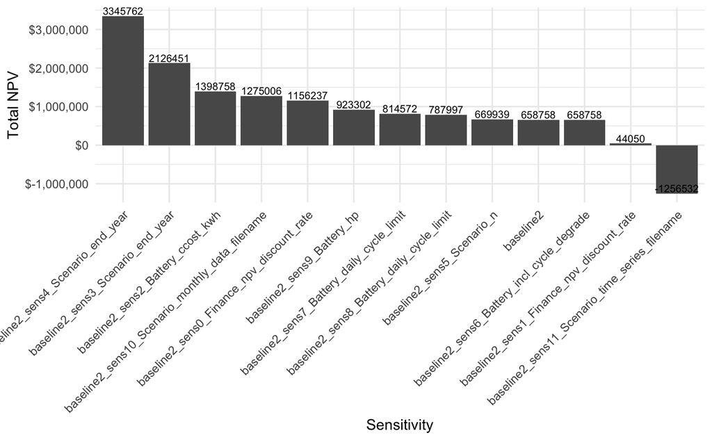

```r
ggplot(outputbl2,aes(x = reorder(shortname,-total), y = total)) + geom_col() +
  theme_minimal() +
  scale_y_continuous(labels = scales::dollar_format()) +
  theme(axis.text.x = element_text(angle = 45, vjust = 1, hjust=1)) +
  labs(y = "Total NPV", x="Sensitivity")+
  geom_text(aes(label=round(total)), vjust=-0.2, size = 2.7)
```

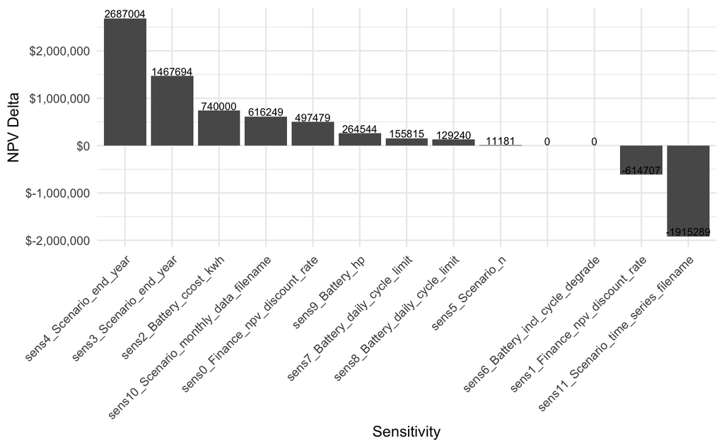

```r
#normalize
base = which(outputbl2$shortname == "baseline2")
bl2_normalized = outputbl2 %>%
  mutate(tot_diff = total - outputbl2$total[base])
ggplot(bl2_normalized,aes(x = reorder(substr(shortname,11,100),-total), y = tot_diff)) + geom_col() +
  theme_minimal() +
  scale_y_continuous(labels = scales::dollar_format()) +
  theme(axis.text.x = element_text(angle = 45, vjust = 1, hjust=1)) +
  labs(y = "NPV Delta", x="Sensitivity")+
  geom_text(aes(label=round(tot_diff)), vjust=-.1, size = 2.7)
```

# Optimistic Baseline: Effect of sensitivities on revenue

Changing the daily cycle limit notably affects FR energy throughput, and reducing FR prices shifts activity towards spinning reserves and DA ETS

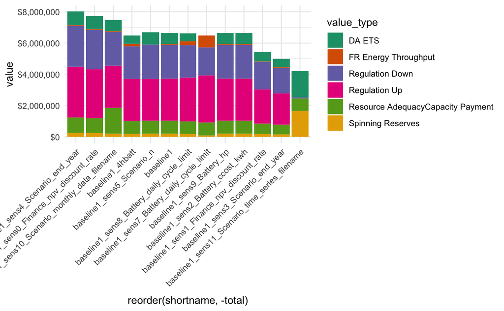

```r
talloutput = pivot_longer(outputbl1, cols = c(`DA ETS`,`FR Energy Throughput`, `Regulation Up`, `Regulation Down`,`Spinning Reserves`,`Non-Spinning Reserves`,`Resource AdequacyCapacity Payment`,
                                              `2MW-5hr Capital Cost`, `2MW-5hr Fixed O&M Cost`,`2MW-5hr Variable O&M Costs`,`Site Load Capital Cost`,`Site Load Fixed O&M Cost`, SGIP, ITC),
                            # c(-runID,-total,-outputfol,-shortname,-description),
                            names_to = "value_type", values_to = "value")  #removed -keyFn
talloutput$name = substr(talloutput$outputfol,10,100)
tallrevenue = filter(talloutput,value>0)
ggplot(tallrevenue,aes(fill = value_type, x = reorder(shortname,-total), y = value)) +
  geom_bar(position="stack", stat = "identity") +
  # geom_hline(yintercept = 0, color = "black") +
  theme_minimal() +
  # theme(axis.text.x = element_text(angle = 90, vjust = 0, hjust=1)) +
  theme(axis.text.x = element_text(angle = 45, vjust = 1, hjust=1)) +
  scale_y_continuous(labels = scales::dollar_format()) +
  scale_fill_brewer(palette = "Dark2") # +
```

# Optimistic Baseline: Effect of sensitivities on costs

The only visible effect is on capital cost, though decreasing FR prices results in some costs associated with FR energy throughput. Interestingly, DA ETS (energy arbitrage) appears as negative in some scenarios, indicating that it was charging in the energy market to be dispatched later in another market.

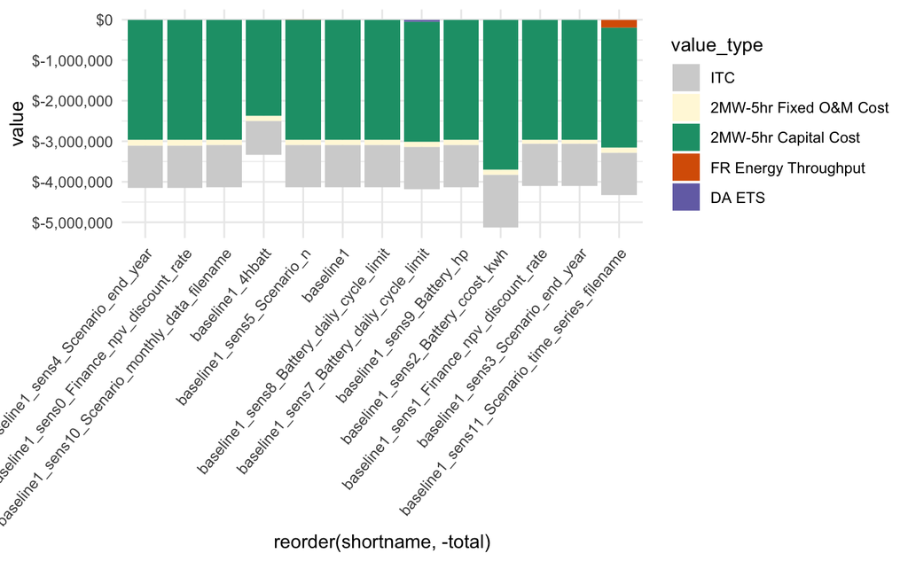

```r
  tallcost = filter(talloutput,value<0)
  tallcost$value_type = ordered(tallcost$value_type, levels = rev(c("DA ETS","FR Energy Throughput","Regulation Up","Regulation Down","Spinning Reserves","Non-Spinning Reserves",
                                                                          "Resource AdequacyCapacity Payment", "2MW-5hr Capital Cost","2MW-5hr Fixed O&M Cost","2MW-5hr Variable O&M Costs",
                                                                          "Site Load Capital Cost","Site Load Fixed O&M Cost",
                                                                          "Aux Load Cost","ITC","SGIP")))
  ggplot(tallcost,aes(fill = value_type, x = reorder(shortname,-total), y = value)) +
    geom_bar(position="stack", stat = "identity") +
    # geom_hline(yintercept = 0, color = "black") +
    theme_minimal() +
    theme(axis.text.x = element_text(angle = 50, vjust = 1, hjust=1)) +
    scale_y_continuous(labels = scales::dollar_format()) +
    scale_fill_manual(values = c("light grey","cornsilk",dark2scale))
```

# Pessimistic Baseline: Effect of sensitivities on revenue

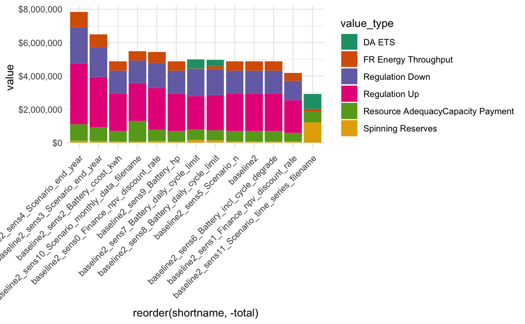

```r
talloutput = pivot_longer(outputbl2, cols = c(-runID,-total,-unsub_total,-outputfol,-shortname,-description),names_to = "value_type", values_to = "value")  #removed -keyFn
talloutput$name = substr(talloutput$outputfol,10,100)
tallrevenue = filter(talloutput,value>0)
ggplot(tallrevenue,aes(fill = value_type, x = reorder(shortname,-total), y = value)) +
  geom_bar(position="stack", stat = "identity") +
  # geom_hline(yintercept = 0, color = "black") +
  theme_minimal() +
  # theme(axis.text.x = element_text(angle = 90, vjust = 0, hjust=1)) +
  theme(axis.text.x = element_text(angle = 45, vjust = 1, hjust=1)) +
  scale_y_continuous(labels = scales::dollar_format()) +
  scale_fill_brewer(palette = "Dark2") # +
```

# Pessimistic Baseline: Effect of sensitivities on cost

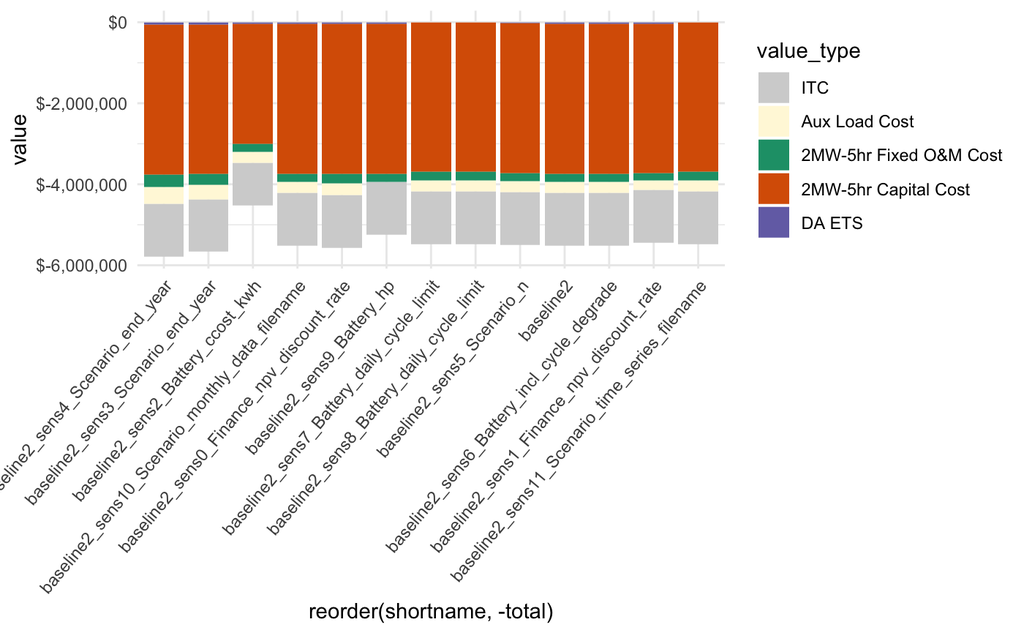

```r
  tallcost = filter(talloutput,value<0)
  tallcost$value_type = ordered(tallcost$value_type, levels = rev(c("DA ETS","FR Energy Throughput","Regulation Up","Regulation Down","Spinning Reserves","Non-Spinning Reserves",
                                                                          "Resource AdequacyCapacity Payment", "2MW-5hr Capital Cost","2MW-5hr Fixed O&M Cost","2MW-5hr Variable O&M Costs",
                                                                          "Site Load Capital Cost","Site Load Fixed O&M Cost",
                                                                          "Aux Load Cost","ITC","SGIP")))
  ggplot(tallcost,aes(fill = value_type, x = reorder(shortname,-total), y = value)) +
    geom_bar(position="stack", stat = "identity") +
    # geom_hline(yintercept = 0, color = "black") +
    theme_minimal() +
    theme(axis.text.x = element_text(angle = 50, vjust = 1, hjust=1)) +
    scale_y_continuous(labels = scales::dollar_format()) +
    scale_fill_manual(values = c("light grey","cornsilk",dark2scale))
```

# Takeaways and todos:

Need to look into effects on FR Energy Throughput and understand what is happening there.

Also to do: Add lower cap costs to optimistic sensitivities (10% lower?), and look at ITC & SGIP assumption sensitivities.

Also need to look into a more rigorous way to quantify sensitivity importance especially if I end up taking a monte carlo sampling approach for uncertainties.